```python
import pandas as pd
import numpy as np
import statistics as st
import matplotlib.pyplot as plt
import matplotlib
import seaborn as sns
from scipy import stats
%pylab inline
```

# A Jouney into Titanic's passengers data

## Introduction

In this notebook, I'll analyze a dataset containing demographics and passenger information from 891 of the 2224 passengers and crew on board the Titanic. Although there was some element of luck involved in surviving the sinking, we can assume that some groups of people were more likely to survive than others.

In this analysis, I'll look for patterns that describe how the population who survived the sinking differed from the population who didn't. Based on what we know about the accident, that women and children were prioritized and probably class influenced who were evacuated first, here are the quesitons I'm going to explore:

### Exploratory Questions

1. **How does survival rate change by class? Are wealthier individuals (1st class) more likely to survive than the poor (3rd class)?**
2. **How does survival rate change by gender? Does gender affect the chances of surviving?**
3. **How does age impact survival rates? Are older people more likely to die?**

## Importing CSV data into a Pandas DataFrame

```python
titanic_filepath = '/Users/Adan/Google Drive/Courses/Data Analyst Nanodegree/Projects/P2- Investigate a Dataset/titanic_data.csv'
raw_titanic_df = pd.read_csv(titanic_filepath)
raw_titanic_df.head(3)
```

|  | PassengerId | Survived | Pclass | Name | Sex | Age | SibSp | Parch | Ticket | Fare | Cabin | Embarked |
| --- | --- | --- | --- | --- | --- | --- | --- | --- | --- | --- | --- | --- |
| 0 | 1 | 0 | 3 | Braund, Mr. Owen Harris | male | 22 | 1 | 0 | A/5 21171 | 7.2500 | NaN | S |
| 1 | 2 | 1 | 1 | Cumings, Mrs. John Bradley (Florence Briggs Th... | female | 38 | 1 | 0 | PC 17599 | 71.2833 | C85 | C |
| 2 | 3 | 1 | 3 | Heikkinen, Miss. Laina | female | 26 | 0 | 0 | STON/O2. 3101282 | 7.9250 | NaN | S |

## Treating and Cleaning data

```python
# Getting summary info from raw dataframe
raw_titanic_df.info()
```

```
<class 'pandas.core.frame.DataFrame'>
Int64Index: 891 entries, 0 to 890
Data columns (total 12 columns):
PassengerId    891 non-null int64
Survived       891 non-null int64
Pclass         891 non-null int64
Name           891 non-null object
Sex            891 non-null object
Age            714 non-null float64
SibSp          891 non-null int64
Parch          891 non-null int64
Ticket         891 non-null object
Fare           891 non-null float64
Cabin          204 non-null object
Embarked       889 non-null object
dtypes: float64(2), int64(5), object(5)
memory usage: 90.5+ KB
```

```python
# Dropping unnecessary (that won't be used in the analysis) columns from raw dataframe
clean_titanic_df = raw_titanic_df.drop(['PassengerId','Ticket', 'Cabin'], axis=1)
# Getting summary info from cleaned dataframe
clean_titanic_df.info()
```

```
<class 'pandas.core.frame.DataFrame'>
Int64Index: 891 entries, 0 to 890
Data columns (total 9 columns):
Survived    891 non-null int64
Pclass      891 non-null int64
Name        891 non-null object
Sex         891 non-null object
Age         714 non-null float64
SibSp       891 non-null int64
Parch       891 non-null int64
Fare        891 non-null float64
Embarked    889 non-null object
dtypes: float64(2), int64(4), object(3)
memory usage: 69.6+ KB
```

```python
# Filtering data set to only those passangers with full features infromation
full_titanic_df = clean_titanic_df.dropna()
# Getting summary info from full dataframe
full_titanic_df.info()
```

```
<class 'pandas.core.frame.DataFrame'>
Int64Index: 712 entries, 0 to 890
Data columns (total 9 columns):
Survived    712 non-null int64
Pclass      712 non-null int64
Name        712 non-null object
Sex         712 non-null object
Age         712 non-null float64
SibSp       712 non-null int64
Parch       712 non-null int64
Fare        712 non-null float64
Embarked    712 non-null object
dtypes: float64(2), int64(4), object(3)
memory usage: 55.6+ KB
```

```python
#Creating a new treated dataframe
pd.options.mode.chained_assignment = None
titanic_df = full_titanic_df
titanic_df['Male'] = (titanic_df['Sex'] == 'male')
titanic_df['Female'] = (titanic_df['Sex'] == 'female')

titanic_df['Baby'] =  (titanic_df.Age <= 2)
titanic_df['Child'] = ((titanic_df.Age <= 12) & (titanic_df.Age > 2))
titanic_df['Young'] = ((titanic_df.Age < 20) & (titanic_df.Age > 12))
titanic_df['Adult'] = ((titanic_df.Age < 60) & (titanic_df.Age >= 20))
titanic_df['Old'] =  (titanic_df.Age >= 60)

titanic_df['Family?'] =  ((titanic_df.SibSp > 0) | (titanic_df.Parch > 0))

titanic_df['1st_Class'] =  (titanic_df.Pclass == 1)
titanic_df['2nd_Class'] =  (titanic_df.Pclass == 2)
titanic_df['3rd_Class'] =  (titanic_df.Pclass == 3)

titanic_df['AgeGroup'] = np.where(titanic_df.Baby == True, 1, 0)
titanic_df['AgeGroup'] = np.where(titanic_df.Child == True, 2, titanic_df['AgeGroup'])
titanic_df['AgeGroup'] = np.where(titanic_df.Young == True, 3, titanic_df['AgeGroup'])
titanic_df['AgeGroup'] = np.where(titanic_df.Adult == True, 4, titanic_df['AgeGroup'])
titanic_df['AgeGroup'] = np.where(titanic_df.Old == True, 5, titanic_df['AgeGroup'])

titanic_df.head(2)
```

|  | Survived | Pclass | Name | Sex | Age | SibSp | Parch | Fare | Embarked | Male | ... | Baby | Child | Young | Adult | Old | Family? | 1st_Class | 2nd_Class | 3rd_Class | AgeGroup |
| --- | --- | --- | --- | --- | --- | --- | --- | --- | --- | --- | --- | --- | --- | --- | --- | --- | --- | --- | --- | --- | --- |
| 0 | 0 | 3 | Braund, Mr. Owen Harris | male | 22 | 1 | 0 | 7.2500 | S | True | ... | False | False | False | True | False | True | False | False | True | 4 |
| 1 | 1 | 1 | Cumings, Mrs. John Bradley (Florence Briggs Th... | female | 38 | 1 | 0 | 71.2833 | C | False | ... | False | False | False | True | False | True | True | False | False | 4 |

2 rows × 21 columns

## Overall Statistics

This samples's survival rate is 40.45%, higher than the official survival rate(*) of 32.2%*. Our dataset contains a greater proportion of survivers maybe because (we can assume that) it's easier to collect data from them than from the passangers who didn't make it. And, if this hypothesis is correct, this tendency might have been intensified by removing the passengers with NaN vaiues - again, assuming that we might have less information from non survivers.

Only 43.5% of passangers were accompained by family.

The mean fare price is 34.56, but more than 75% of the passangers paid less than that.

63.6% of the passangers in the sample are males and 36.4%, females.

(*)from British Parliamentary Papers, 1912

```python
# Getting summary of full dataframe statistics
titanic_df.describe()
```

|  | Survived | Pclass | Age | SibSp | Parch | Fare | Male | Female | Baby | Child | Young | Adult | Old | Family? | 1st_Class | 2nd_Class | 3rd_Class | AgeGroup |
| --- | --- | --- | --- | --- | --- | --- | --- | --- | --- | --- | --- | --- | --- | --- | --- | --- | --- | --- |
| count | 712.000000 | 712.000000 | 712.000000 | 712.000000 | 712.000000 | 712.000000 | 712 | 712 | 712 | 712 | 712 | 712 | 712 | 712 | 712 | 712 | 712 | 712.000000 |
| mean | 0.404494 | 2.240169 | 29.642093 | 0.514045 | 0.432584 | 34.567251 | 0.636236 | 0.363764 | 0.0337079 | 0.0632022 | 0.133427 | 0.734551 | 0.0351124 | 0.435393 | 0.258427 | 0.242978 | 0.498596 | 3.674157 |
| std | 0.491139 | 0.836854 | 14.492933 | 0.930692 | 0.854181 | 52.938648 | 0.48142 | 0.48142 | 0.180603 | 0.243497 | 0.340275 | 0.441883 | 0.184193 | 0.496157 | 0.438078 | 0.429183 | 0.50035 | 0.787030 |
| min | 0.000000 | 1.000000 | 0.420000 | 0.000000 | 0.000000 | 0.000000 | False | False | False | False | False | False | False | False | False | False | False | 1.000000 |
| 25% | 0.000000 | 1.000000 | 20.000000 | 0.000000 | 0.000000 | 8.050000 | 0 | 0 | 0 | 0 | 0 | 0 | 0 | 0 | 0 | 0 | 0 | 4.000000 |
| 50% | 0.000000 | 2.000000 | 28.000000 | 0.000000 | 0.000000 | 15.645850 | 1 | 0 | 0 | 0 | 0 | 1 | 0 | 0 | 0 | 0 | 0 | 4.000000 |
| 75% | 1.000000 | 3.000000 | 38.000000 | 1.000000 | 1.000000 | 33.000000 | 1 | 1 | 0 | 0 | 0 | 1 | 0 | 1 | 1 | 0 | 1 | 4.000000 |
| max | 1.000000 | 3.000000 | 80.000000 | 5.000000 | 6.000000 | 512.329200 | True | True | True | True | True | True | True | True | True | True | True | 5.000000 |

### Charts

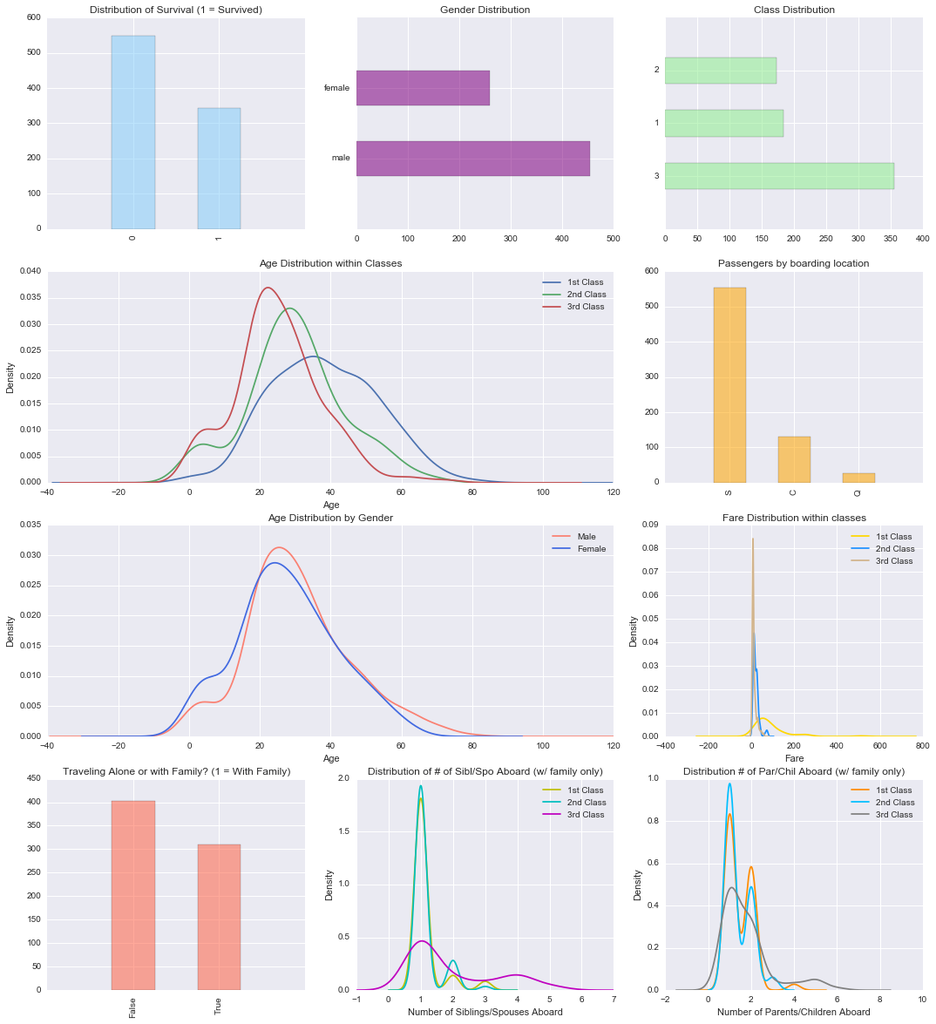

```python
# Specifies the parameters of graphs
fig = plt.figure(figsize=(18,20), dpi=1200)
alpha_bar_chart = 0.55

#1ST PLOT--------: Bar graph of those who surived vs those who did not
# Lets us plot many diffrent shaped graphs together
ax1 = plt.subplot2grid((4,3),(0,0))
raw_titanic_df.Survived.value_counts().plot(kind='bar', alpha=alpha_bar_chart, color='lightskyblue')
# this nicely sets the margins in matplotlib to deal with a recent bug 1.3.1
ax1.set_xlim(-1, 2)
plt.title("Distribution of Survival (1 = Survived)")
#1ST PLOT--------

#2ND PLOT--------: Bar graph of gender distribution
ax2 = plt.subplot2grid((4,3),(0,1))
titanic_df.Sex.value_counts().plot(kind='barh', alpha=alpha_bar_chart, color='purple')
ax2.set_ylim(-1, len(titanic_df.Sex.value_counts()))
plt.title("Gender Distribution")
#2ND PLOT--------

#3RD PLOT--------: Bar graph of the passengers distribution among classes
ax3 = plt.subplot2grid((4,3),(0,2))
titanic_df.Pclass.value_counts().plot(kind="barh", alpha=alpha_bar_chart, color='lightgreen')
ax3.set_ylim(-1, len(titanic_df.Pclass.value_counts()))
plt.title("Class Distribution")
#3RD PLOT--------

#4TH PLOT--------: Kernel desnsity estimate of passanges's age by class
plt.subplot2grid((4,3),(1,0), colspan=2)
titanic_df.Age[titanic_df.Pclass == 1].plot(kind='kde')
titanic_df.Age[titanic_df.Pclass == 2].plot(kind='kde')
titanic_df.Age[titanic_df.Pclass == 3].plot(kind='kde')
plt.xlabel("Age")
plt.title("Age Distribution within Classes")
plt.legend(('1st Class', '2nd Class','3rd Class'),loc='best')
#4TH PLOT--------

#5TH PLOT--------: Bar graph of passengers per boarding location
ax5 = plt.subplot2grid((4,3),(1,2))
titanic_df.Embarked.value_counts().plot(kind='bar', alpha=alpha_bar_chart, color='orange')
ax5.set_xlim(-1, len(titanic_df.Embarked.value_counts()))
plt.title("Passengers by boarding location")
#5TH PLOT--------

#6TH PLOT--------: Kernel desnsity estimate of passanges's age by gender
plt.subplot2grid((4,3),(2,0), colspan=2)
titanic_df.Age[titanic_df.Sex == 'male'].plot(kind='kde', color='salmon')
titanic_df.Age[titanic_df.Sex == 'female'].plot(kind='kde', color='royalblue')
plt.xlabel("Age")
plt.title("Age Distribution by Gender")
plt.legend(('Male', 'Female'),loc='best')
#6TH PLOT--------

#7TH PLOT--------: Kernel desnsity estimate of fare paid by class
plt.subplot2grid((4,3),(2,2))
titanic_df.Fare[titanic_df.Pclass == 1].plot(kind='kde', color='gold')
titanic_df.Fare[titanic_df.Pclass == 2].plot(kind='kde', color='dodgerblue')
titanic_df.Fare[titanic_df.Pclass == 3].plot(kind='kde', color='tan')
# plots an axis lable
plt.xlabel("Fare")
plt.title("Fare Distribution within classes")
# sets our legend for our graph.
plt.legend(('1st Class', '2nd Class','3rd Class'),loc='best')
#7TH PLOT--------

#8TH PLOT--------: Bar graph of those who alone vs those who were with family
ax8 = plt.subplot2grid((4,3),(3,0))
titanic_df['Family?'].value_counts().plot(kind='bar', alpha=alpha_bar_chart, color='tomato')
ax8.set_xlim(-1, len(titanic_df['Family?'].value_counts()))
plt.title("Traveling Alone or with Family? (1 = With Family)")
#8TH PLOT--------

#9TH PLOT--------: Kernel desnsity of number of Siblings/Spouses Aboard for those who were with family by class
plt.subplot2grid((4,3),(3,1))
titanic_df.SibSp[(titanic_df.Pclass == 1) & (titanic_df.SibSp > 0)].plot(kind='kde', color='y')
titanic_df.SibSp[(titanic_df.Pclass == 2) & (titanic_df.SibSp > 0)].plot(kind='kde', color='c')
titanic_df.SibSp[(titanic_df.Pclass == 3) & (titanic_df.SibSp > 0)].plot(kind='kde', color='m')
plt.xlabel("Number of Siblings/Spouses Aboard")
plt.title("Distribution of # of Sibl/Spo Aboard (w/ family only)")
plt.legend(('1st Class', '2nd Class','3rd Class'),loc='best')
#9TH PLOT--------

#10TH PLOT--------: Kernel desnsity of number of Parents/Children Aboard for those who were with family by class
plt.subplot2grid((4,3),(3,2))
titanic_df.Parch[(titanic_df.Pclass == 1) & (titanic_df.Parch > 0)].plot(kind='kde', color='darkorange')
titanic_df.Parch[(titanic_df.Pclass == 2) & (titanic_df.Parch > 0)].plot(kind='kde', color='deepskyblue')
titanic_df.Parch[(titanic_df.Pclass == 3) & (titanic_df.Parch > 0)].plot(kind='kde', color='grey')
plt.xlabel("Number of Parents/Children Aboard")
plt.title("Distribution # of Par/Chil Aboard (w/ family only)")
plt.legend(('1st Class', '2nd Class','3rd Class'),loc='best')
#10TH PLOT--------
```

#### Observations

From the charts, we can notice some insteresting trends.

## Exploring the Questions

### 1. How does survival rate change by class?

#### Analyzing Observations

If we calculate the survival rate and plot the number of people who survived and died for each class, from the sample we get that being from a higher class leads to a greater survival rate.

As calculated below for the sample, the 1st class survival rate is 65.2%, while the 2nd class rate is 48.0% and the 3rd's is 23.9%.

```python
# Calculating survival rates for each class
print 'Survival Rate for each class is'
print '- 1st Class: %1.3f' %(titanic_df.Survived[titanic_df.Pclass == 1].mean())
print '- 2nd Class: %1.3f' %(titanic_df.Survived[titanic_df.Pclass == 2].mean())
print '- 3rd Class: %1.3f' %(titanic_df.Survived[titanic_df.Pclass == 3].mean())
```

```
Survival Rate for each class is
- 1st Class: 0.652
- 2nd Class: 0.480
- 3rd Class: 0.239
```

```
 <a list of 3 Text xticklabel objects>)
```

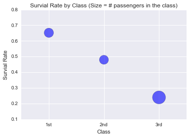

```python
# Plotting survival rate by class
class_survival_rate_df = titanic_df.groupby('Pclass').mean().reset_index()
plt.scatter(class_survival_rate_df.Pclass, class_survival_rate_df.Survived,alpha= 0.6, s=2*titanic_df.groupby('Pclass').count()['Survived'].values)
plt.xlabel("Class")
plt.ylabel("Survial Rate")
plt.title("Survial Rate by Class (Size = # passengers in the class)")
plt.xticks(class_survival_rate_df.Pclass, ['1st', '2nd', '3rd'])
```

*Are these differences significant?*

From the p-values calculated below, even at a confidence level of 99%, these differences are significant. So, we can affirm that in Titatic the survival rate changed by class, with wealthier individuals (1st class) being more likely to survive than the poor (3rd class).

```python
# Calculating t Statistics for each difference in survival rate among classes
print 't-Test results for differences in survival rates:'
print ''
print '- 1st and 3rd classes, p=%f' %(stats.ttest_ind(titanic_df.Survived[titanic_df.Pclass == 1], titanic_df.Survived[titanic_df.Pclass == 3], equal_var=False)[1])
print '- 1st and 2nd classes, p=%f' %(stats.ttest_ind(titanic_df.Survived[titanic_df.Pclass == 1], titanic_df.Survived[titanic_df.Pclass == 2], equal_var=False)[1])
print '- 2nd and 3rd classes, p=%f' %(stats.ttest_ind(titanic_df.Survived[titanic_df.Pclass == 2], titanic_df.Survived[titanic_df.Pclass == 3], equal_var=False)[1])
```

```
t-Test results for differences in survival rates:

- 1st and 3rd classes, p=0.000000
- 1st and 2nd classes, p=0.000982
- 2nd and 3rd classes, p=0.000000
```

*Going Deeper*

Even though the results are significant if we look at classes separately, they might be due to other variables with strong correlation to survival and which may have different distributions across classes. One variable that likely causes the difference is gender. So, it's worth taking a look at survival rates across classes for different genders, and analyzing how class influences survival for each gender. That's what we do below:

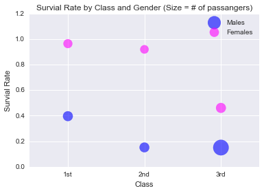

```python
# Plotting survival rate by class and gender
class_survival_rate_males_df = titanic_df[titanic_df.Sex == 'male'].groupby('Pclass').mean().reset_index()
plt.scatter(class_survival_rate_males_df.Pclass, class_survival_rate_males_df.Survived,alpha= 0.6, s=2*titanic_df[titanic_df.Sex == 'male'].groupby('Pclass').count()['Survived'].values, color='b')
class_survival_rate_females_df = titanic_df[titanic_df.Sex == 'female'].groupby('Pclass').mean().reset_index()
plt.scatter(class_survival_rate_females_df.Pclass, class_survival_rate_females_df.Survived,alpha= 0.6, s=2*titanic_df[titanic_df.Sex == 'female'].groupby('Pclass').count()['Survived'].values, color='magenta')

plt.xlabel("Class")
plt.ylabel("Survial Rate")
plt.title("Survial Rate by Class and Gender (Size = # of passangers)")
plt.xticks(class_survival_rate_males_df.Pclass, ['1st', '2nd', '3rd'])
plt.legend(('Males', 'Females'),loc='best')
```

```python
# Calculating survival rates for each gender and class group
print 'Survival Rate for each class and gender is'
print ''
print '- 1st Class Males: %1.3f' %(titanic_df.Survived[(titanic_df.Pclass == 1) & (titanic_df.Sex == 'male')].mean())
print '- 2nd Class Males: %1.3f' %(titanic_df.Survived[(titanic_df.Pclass == 2) & (titanic_df.Sex == 'male')].mean())
print '- 3rd Class Males: %1.3f' %(titanic_df.Survived[(titanic_df.Pclass == 3) & (titanic_df.Sex == 'male')].mean())
print ''
print '- 1st Class Females: %1.3f' %(titanic_df.Survived[(titanic_df.Pclass == 1) & (titanic_df.Sex == 'female')].mean())
print '- 2nd Class Females: %1.3f' %(titanic_df.Survived[(titanic_df.Pclass == 2) & (titanic_df.Sex == 'female')].mean())
print '- 3rd Class Females: %1.3f' %(titanic_df.Survived[(titanic_df.Pclass == 3) & (titanic_df.Sex == 'female')].mean())
```

```
Survival Rate for each class and gender is

- 1st Class Males: 0.396
- 2nd Class Males: 0.152
- 3rd Class Males: 0.150

- 1st Class Females: 0.964
- 2nd Class Females: 0.919
- 3rd Class Females: 0.461
```

From the charts and data above, we can notice that survival rates change a lot for different genders - a fact that we'll explore in the next question. And though we can notice that within each gender survival rate increases for higher classes, their differences are not as signigificant as if we looked at classes alone. That indicates that what we suspected is true: the different distribution of gender within each class accounts for part of the differences in survival rates.

But how significant are these differences? Next, we explore it.

#### Statistical Tests

```python
# Calculating t Statistics for each difference in survival rate among classes and gender
print 't-Test results for differences in survival rates:'
print ''
print '- Males in 1st and 3rd classes, p=%f' %(stats.ttest_ind(titanic_df.Survived[(titanic_df.Pclass == 1) & (titanic_df.Sex == 'male')], titanic_df.Survived[(titanic_df.Pclass == 3) & (titanic_df.Sex == 'male')], equal_var=False)[1])
print '- Males in 1st and 2nd classes, p=%f' %(stats.ttest_ind(titanic_df.Survived[(titanic_df.Pclass == 1) & (titanic_df.Sex == 'male')], titanic_df.Survived[(titanic_df.Pclass == 2) & (titanic_df.Sex == 'male')], equal_var=False)[1])
print '- Males in 2nd and 3rd classes, p=%f' %(stats.ttest_ind(titanic_df.Survived[(titanic_df.Pclass == 2) & (titanic_df.Sex == 'male')], titanic_df.Survived[(titanic_df.Pclass == 3) & (titanic_df.Sex == 'male')], equal_var=False)[1])
print ''
print '- Females in 1st and 3rd classes, p=%f' %(stats.ttest_ind(titanic_df.Survived[(titanic_df.Pclass == 1) & (titanic_df.Sex == 'female')], titanic_df.Survived[(titanic_df.Pclass == 3) & (titanic_df.Sex == 'female')], equal_var=False)[1])
print '- Females in 1st and 2nd classes, p=%f' %(stats.ttest_ind(titanic_df.Survived[(titanic_df.Pclass == 1) & (titanic_df.Sex == 'female')], titanic_df.Survived[(titanic_df.Pclass == 2) & (titanic_df.Sex == 'female')], equal_var=False)[1])
print '- Females in 2nd and 3rd classes, p=%f' %(stats.ttest_ind(titanic_df.Survived[(titanic_df.Pclass == 2) & (titanic_df.Sex == 'female')], titanic_df.Survived[(titanic_df.Pclass == 3) & (titanic_df.Sex == 'female')], equal_var=False)[1])
```

```
t-Test results for differences in survival rates:

- Males in 1st and 3rd classes, p=0.000011
- Males in 1st and 2nd classes, p=0.000086
- Males in 2nd and 3rd classes, p=0.975386

- Females in 1st and 3rd classes, p=0.000000
- Females in 1st and 2nd classes, p=0.239446
- Females in 2nd and 3rd classes, p=0.000000
```

#### Conclusion

With the t-Tests calculated above, we can conclude that:

- For men, the differences in survival rate from the 1st class to the 2nd and 3rd classes are significant. But the difference between the 2nd and the 3rd isn't significant. So we can say that for men, being from the 1st class increased chances of survival when compared to being from the 2nd or 3rd classes, which had about the same survival rate.
- For women, the differences in survival rate from the 3rd class to the 1st and 2nd classes are significant. But the difference between the 1st and the 2nd isn't significant. So, for women, being from either the 1st or 2nd class didn't change the chance of survival significantly, but being from the 3rd class made them half as likely to survive.

### 2. How does survival rate change by gender?

#### Analyzing Observations

In this sample, following what we expected from knowing that women were evacuated first, we see a strong difference in survival rates based on gender, indicating that women were more likely to survive than men.

As shown in the calculations below, women's survival rate was 75.3% and men's, 20.5%.

```python
# Calculating survival rates for each gender
print 'Survival Rate for each gender is'
print '- Males: %1.3f' %(titanic_df.Survived[titanic_df.Sex == 'male'].mean())
print '- Females: %1.3f' %(titanic_df.Survived[titanic_df.Sex == 'female'].mean())
```

```
Survival Rate for each gender is
- Males: 0.205
- Females: 0.753
```

```
 <a list of 2 Text xticklabel objects>)
```

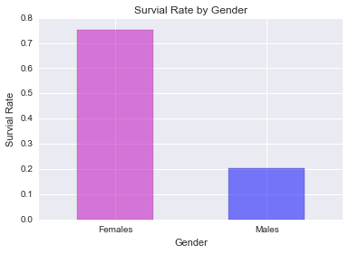

```python
# Plotting survival rate by gender
gender_survival_rate_df = titanic_df.groupby('Sex').mean().reset_index()
plot = gender_survival_rate_df.Survived.plot(kind='bar', color='mb', alpha=0.5)
plt.xlabel("Gender")
plt.ylabel("Survial Rate")
plt.title("Survial Rate by Gender")
plt.xticks([0, 1], ['Females', 'Males'],rotation='horizontal')
```

#### Statistical Test

```python
# Calculating t Statistics for gender survival rates difference
print 't-Test result for the difference in survival rates:'
print ''
print 'for males and females, t=%f' %(stats.ttest_ind(titanic_df.Survived[titanic_df.Sex == 'female'], titanic_df.Survived[titanic_df.Sex == 'male'], equal_var=False)[0])
print 'and p=%f' %(stats.ttest_ind(titanic_df.Survived[titanic_df.Sex == 'female'], titanic_df.Survived[titanic_df.Sex == 'male'], equal_var=False)[1])
```

```
t-Test result for the difference in survival rates:

for males and females, t=16.647056
and p=0.000000
```

#### Conclusion

From the t-Test results above, we can conclude that the difference in survival rates between women and men are significant. So, in fact women were more likely to survive than men.

### 3. How does age impact survival rates?

To descrease the granularity of age, I've created 5 age groups to encapsulate different age ranges:

- Babies = up to 2 years old
- Children = from 3 to 12 years old
- Young = from 13 to 19 years old
- Adult = from 20 to 59 years old
- Old = more than 60 years old

Below, we examine the survival rates for each of these groups and discuss if they're significant.

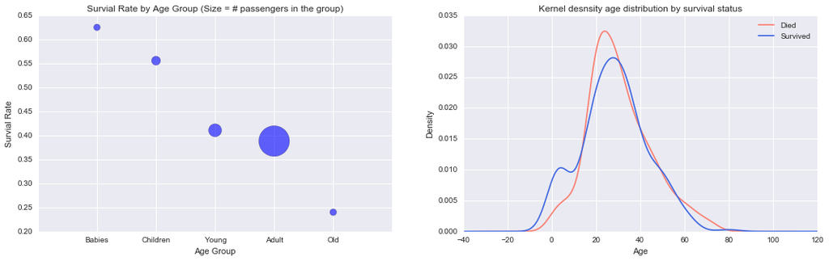

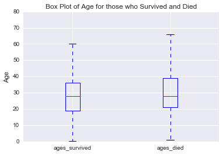

```python
# Creating Plots
fig = plt.figure(figsize=(18,5), dpi=1200)

#1ST PLOT--------: Scatter plot of survival rate by age group
ax1 = plt.subplot2grid((1,2),(0,0))
age_survival_rate_df = titanic_df.groupby('AgeGroup').mean().reset_index()
plt.scatter(age_survival_rate_df.AgeGroup, age_survival_rate_df.Survived,alpha= 0.6, s=3*titanic_df.groupby('AgeGroup').count()['Survived'].values)
plt.xlabel("Age Group")
plt.ylabel("Survial Rate")
plt.title("Survial Rate by Age Group (Size = # passengers in the group)")
ax1.set_xticklabels(['', 'Babies', 'Children', 'Young', 'Adult', 'Old', ''])
#1ST PLOT--------

#2ND PLOT--------: Kernel desnsity estimate of passanges's age for survivers and non suvivers
ax2 = plt.subplot2grid((1,2),(0,1))
titanic_df.Age[titanic_df.Survived == 0].plot(kind='kde', color='salmon')
titanic_df.Age[titanic_df.Survived == 1].plot(kind='kde', color='royalblue')
plt.xlabel("Age")
plt.title("Kernel desnsity age distribution by survival status")
plt.legend(('Died', 'Survived'),loc='best')
#2ND PLOT--------

#3RD PLOT--------: Box plots of age for survivers and non survivers
age_groups_df = pd.DataFrame()
age_groups_df['ages_survived'] = titanic_df.Age[titanic_df.Survived==1].values
age_groups_df = age_groups_df.reindex(range(0, len(titanic_df.Age[titanic_df.Survived==0].values), 1))
age_groups_df['ages_died'] = titanic_df.Age[titanic_df.Survived==0].values
age_groups_df.plot(kind='box')
plt.ylabel('Age')
plt.title('Box Plot of Age for those who Survived and Died')
#3RD PLOT--------
```

```python
# Calculating survival rates for each age group
print 'Survival Rate for each age group is'
print '- Babies: %1.3f' %(titanic_df.Survived[titanic_df['AgeGroup'] == 1].mean())
print '- Children: %1.3f' %(titanic_df.Survived[titanic_df['AgeGroup'] == 2].mean())
print '- Young Adults: %1.3f' %(titanic_df.Survived[titanic_df['AgeGroup'] == 3].mean())
print '- Adults: %1.3f' %(titanic_df.Survived[titanic_df['AgeGroup'] == 4].mean())
print '- Old: %1.3f' %(titanic_df.Survived[titanic_df['AgeGroup'] == 5].mean())
```

```
Survival Rate for each age group is
- Babies: 0.625
- Children: 0.556
- Young Adults: 0.411
- Adults: 0.388
- Old: 0.240
```

#### Analyzing Observations

From the results and charts above we can notice a general trend for survivers being younger than the ones who died.

In the first chart, where we plot the survival rates for each of the age groups - and where the area of the bubles represent the group size, we can see a tendency of decreased survival rate for older people. Here, we can also notice that the greatest age group aboard were adults.

In the second and third charts, comparing the age distribution of survivers and non survivers, though the differences aren't very strong, we can observe that survivers had a greater density of young people.

In the boxplots of age for the two groups, we can see that the age distribution is very smiliar among survivers and non survivers. But we can distinct a thinner and younger distribution for the survivers, even though the means seem to be the same. The fact that most passagers were adults may explain the big similarity of age distribution between the two.

Finally, calculating the survival rates for each age group, we get a clear trend: the older the group, the lower is the survival rate. But are these differences significant? We explore this question with the t-Test performed below:

#### Statistical Tests

```python
# Calculating t Statistics for each age group survival rate differences
print '- Babies and Children, p=%f' %(stats.ttest_ind(titanic_df.Survived[titanic_df['AgeGroup'] == 1], titanic_df.Survived[titanic_df['AgeGroup'] == 2], equal_var=False)[1])
print '- Babies and Young, p=%f' %(stats.ttest_ind(titanic_df.Survived[titanic_df['AgeGroup'] == 1], titanic_df.Survived[titanic_df['AgeGroup'] == 3], equal_var=False)[1])
print '- Babies and Adults, p=%f' %(stats.ttest_ind(titanic_df.Survived[titanic_df['AgeGroup'] == 1], titanic_df.Survived[titanic_df['AgeGroup'] == 4], equal_var=False)[1])
print '- Babies and Old, p=%f' %(stats.ttest_ind(titanic_df.Survived[titanic_df['AgeGroup'] == 1], titanic_df.Survived[titanic_df['AgeGroup'] == 5], equal_var=False)[1])
print ''
print '- Children and Young, p=%f' %(stats.ttest_ind(titanic_df.Survived[titanic_df['AgeGroup'] == 2], titanic_df.Survived[titanic_df['AgeGroup'] == 3], equal_var=False)[1])
print '- Children and Adults, p=%f' %(stats.ttest_ind(titanic_df.Survived[titanic_df['AgeGroup'] == 2], titanic_df.Survived[titanic_df['AgeGroup'] == 4], equal_var=False)[1])
print '- Children and Old, p=%f' %(stats.ttest_ind(titanic_df.Survived[titanic_df['AgeGroup'] == 2], titanic_df.Survived[titanic_df['AgeGroup'] == 5], equal_var=False)[1])
print ''
print '- Young and Adults, p=%f' %(stats.ttest_ind(titanic_df.Survived[titanic_df['AgeGroup'] == 3], titanic_df.Survived[titanic_df['AgeGroup'] == 4], equal_var=False)[1])
print '- Young and Old, p=%f' %(stats.ttest_ind(titanic_df.Survived[titanic_df['AgeGroup'] == 3], titanic_df.Survived[titanic_df['AgeGroup'] == 5], equal_var=False)[1])
print ''
print '- Adults and Old, p=%f' %(stats.ttest_ind(titanic_df.Survived[titanic_df['AgeGroup'] == 4], titanic_df.Survived[titanic_df['AgeGroup'] == 5], equal_var=False)[1])
```

```
- Babies and Children, p=0.583226
- Babies and Young, p=0.065799
- Babies and Adults, p=0.030323
- Babies and Old, p=0.005929

- Children and Young, p=0.112647
- Children and Adults, p=0.036336
- Children and Old, p=0.008114

- Young and Adults, p=0.684949
- Young and Old, p=0.098363

- Adults and Old, p=0.110415
```

#### Conclusion

From the statistical tests results above, we can notice an interesting fact: though we observe decreasing survival rates for older groups, most of these differences aren't significant at a confidence level of 95%. But here's what we can conclude with 95% confidence:

- babies and children, in other words, passanger up to 12 years old were more likely to survive than adults and old people (more than 20 years old);
- babies and children weren't siginificantly more likely to survive than young passengers (from 13 to 19 years old);
- we didn't observe significant survival rate differences among young, adult and old passangers (all those older than 12 years old).

## References

[Titanic: Machine Learning from Disaster in kaggle.com](https://www.kaggle.com/c/titanic/data)